# EDA dashboard

# Obj 1 Data dashboard for resistant vs susceptible (in the field)

Turned out the NA is due to  
1. Non-measured field resistance in the poplars from national collection.  
2. Non-active infection in certain controls.

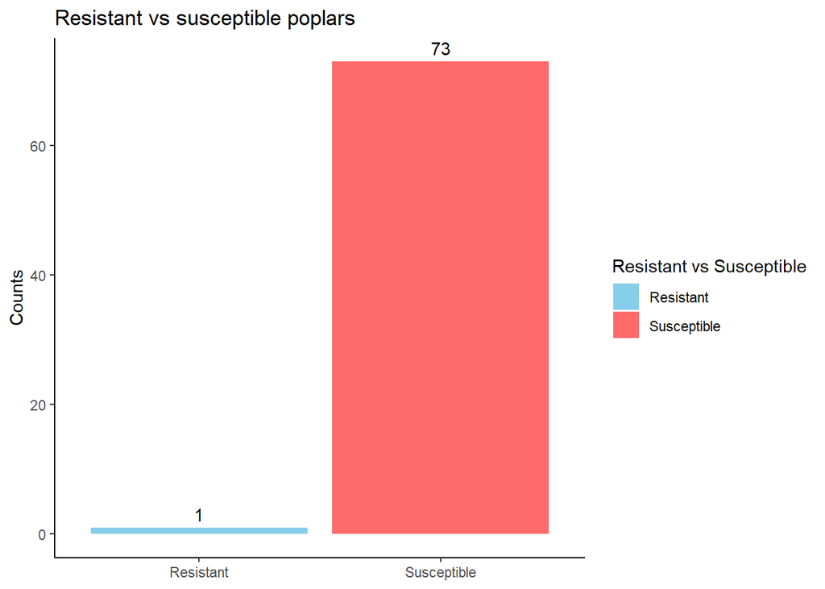

```r
# Resistant poplars in the field: Assigning -5 to NA to avoid confusion in R
wild_yr2000_clean[is.na(wild_yr2000_clean)] = -5

# Add a new variable: resistant vs susceptible
# Loop, -5 = resistant, != -5 susceptible
wild_yr2000_clean[,8] = "NA"

names(wild_yr2000_clean)[8] = "Res_vs_sus_note"

for (i in c(1:nrow(wild_yr2000_clean))) {
  if(wild_yr2000_clean$Notemax.2010[i] == -5)
    wild_yr2000_clean[i,8] = "Resistant"

  if(wild_yr2000_clean$Notemax.2010[i] != -5)
    wild_yr2000_clean[i,8] = "Susceptible"
}

# Plotting resistant vs susceptible poplars in terms of field resistance
(resist_field = ggplot(wild_yr2000_clean, aes(x = Res_vs_sus_note)) +
  geom_bar(aes(fill = Res_vs_sus_note)) +
  geom_text(stat = "count", aes(label = ..count..), vjust = -0.5) +
  labs(title = "Resistant vs susceptible poplars",
       x = "Resistant vs Susceptibe",
       y = "Counts") +
  scale_fill_manual(values = c("#87CEEB", "#FF6A6A"),
                    breaks = c("Resistant", "Susceptible"),
                    name = "Resistant vs Susceptible",
                    labels = c("Resistant", "Susceptible")) +
  theme_classic() +
  theme(axis.title.x = element_blank()))
```

```r
# Checking the population of origin of the resistant poplars
pop = plyr::count(wild_yr2000_clean$Population[
  which(wild_yr2000_clean$Notemax.2010 == -5)
])

names(pop)[1] = "Population"

clone = plyr::count(wild_yr2000_clean$Clone[
  which(wild_yr2000_clean$Notemax.2010 == -5)
])

names(clone)[1] = "Clone"

pop$Clone = paste(clone$Clone)

pop
```

```
##            Population freq     Clone
## 1 St_Genix_sur_Guiers    1 71072-501
```

It seems that there is only one poplar (71072-501) from St Genix that is resistant in the field.

Let’s see the resistant poplars in terms of lab resistance Those with latence = 14 and taille = -5

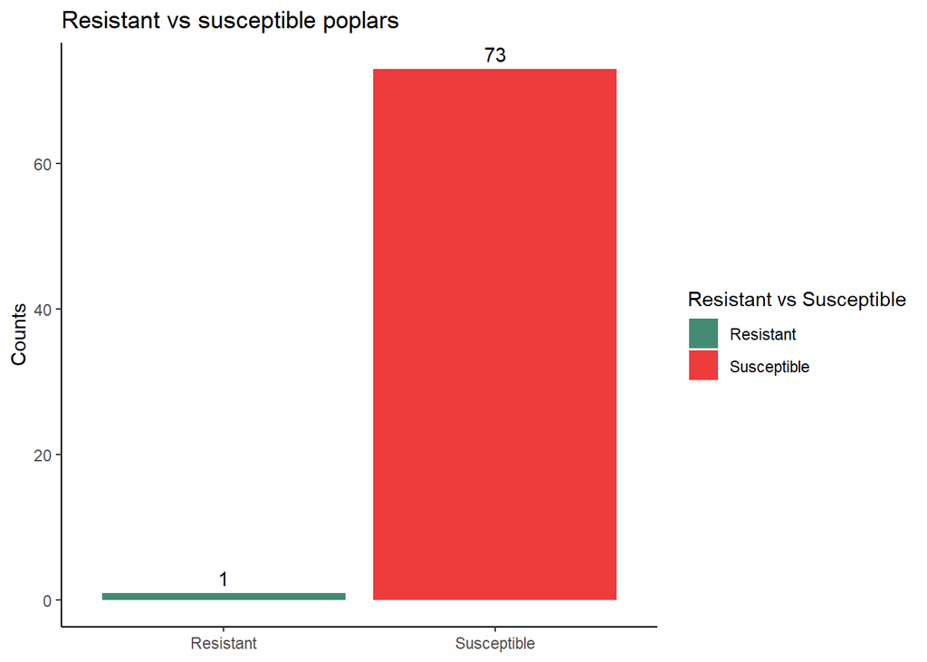

```r
# Add a new variable: resistant vs susceptible (lab)
# Loop, -5 = resistant, != -5 susceptible
wild_yr2000_clean[,9] = "NA"

names(wild_yr2000_clean)[9] = "Res_vs_sus_lab"

for (i in c(1:nrow(wild_yr2000_clean))) {
  if(wild_yr2000_clean$taille.93JE3.2010[i] == -5
     & wild_yr2000_clean$latence.93JE3.2010[i] == 14)
    wild_yr2000_clean[i,9] = "Resistant"

  if(wild_yr2000_clean$taille.93JE3.2010[i] != -5
     & wild_yr2000_clean$latence.93JE3.2010[i] != 14)
    wild_yr2000_clean[i,9] = "Susceptible"
}

# Plotting resistant vs susceptible poplars in terms of lab resistance
(resist_lab = ggplot(wild_yr2000_clean, aes(x = Res_vs_sus_lab)) +
  geom_bar(aes(fill = Res_vs_sus_lab)) +
  geom_text(stat = "count", aes(label = ..count..), vjust = -0.5) +
  labs(title = "Resistant vs susceptible poplars",
       x = "Resistant vs Susceptibe",
       y = "Counts") +
  scale_fill_manual(values = c("#458B74", "#EE3B3B"),
                    breaks = c("Resistant", "Susceptible"),
                    name = "Resistant vs Susceptible",
                    labels = c("Resistant", "Susceptible")) +
  theme_classic() +
  theme(axis.title.x = element_blank()))
```

```r
# Checking the population of origin of the resistant poplars (lab)
pop2 = plyr::count(wild_yr2000_clean$Population[
  which(wild_yr2000_clean$Res_vs_sus_lab == "Resistant")
])

names(pop2)[1] = "Population"

clone2 = plyr::count(wild_yr2000_clean$Clone[
  which(wild_yr2000_clean$Res_vs_sus_lab == "Resistant")
])

names(clone2)[1] = "Clone"

pop2$Clone = paste(clone2$Clone)

pop2
```

```
##   Population freq  Clone
## 1    Nohèdes    1 NOH-25
```

Seems that there are different poplars that are resistant in field and in the lab.

# Obj 2 Average resistance. Data dashboard for summary statistics

```r
# Field resistance (notemax)
# Removing -5 because they're outliers
wild_yr2000_new = wild_yr2000_clean[which(wild_yr2000_clean$Notemax.2010 != -5 &
                                      wild_yr2000_clean$taille.93JE3.2010 != -5), ]

summary(wild_yr2000_new)
```

```
##              Classe          Population         Clone     Notemax.2010
##  coll. Nationale: 0   Nohèdes     :13   6-J05      : 1   Min.   :1.833
##  nigrapop       :64   Ramières    :10   6-J13      : 1   1st Qu.:3.167
##  parent 14x13   : 8   ValAllier   :10   6-J15      : 1   Median :3.833
##  témoin         : 0   Gave-Mauleon: 6   71041-3-402: 1   Mean   :3.654
##                       Baudreix    : 4   71077-2-308: 1   3rd Qu.:4.000
##                       Sauveterre  : 4   92510-1    : 1   Max.   :5.400
##                       (Other)     :25   (Other)    :66
##  latence.93JE3.2010 nbsores.93JE3.2010 taille.93JE3.2010 Res_vs_sus_note
##  Min.   : 7.550     Min.   : 9.556     Min.   :1.667     Length:72
##  1st Qu.: 8.100     1st Qu.:24.275     1st Qu.:3.575     Class :character
##  Median : 8.425     Median :28.950     Median :3.800     Mode  :character
##  Mean   : 8.601     Mean   :30.168     Mean   :3.787
##  3rd Qu.: 8.912     3rd Qu.:36.825     3rd Qu.:4.200
##  Max.   :11.583     Max.   :56.700     Max.   :5.000
##
##  Res_vs_sus_lab
##  Length:72
##  Class :character
##  Mode  :character
##
##
##
##
```

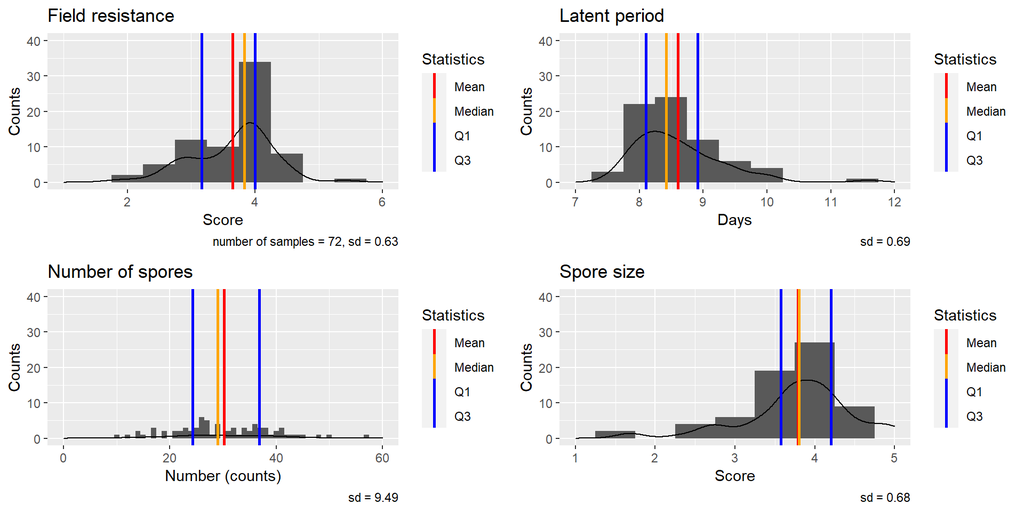

```r
NM = ggplot(wild_yr2000_new, aes(x = Notemax.2010)) +
  geom_histogram(binwidth = 0.5) +
  geom_density(aes(y = 0.3 * ..count..)) +
  geom_vline(aes(xintercept = mean(Notemax.2010), color = "Mean"), size = 1) +
  geom_vline(aes(xintercept = median(Notemax.2010), color = "Median"), size = 1) +
  geom_vline(aes(xintercept = quantile(Notemax.2010, prob = 0.25), color = "Q1"),
             size = 1) +
  geom_vline(aes(xintercept = quantile(Notemax.2010, prob = 0.75), color = "Q3"),
             size = 1) +
  labs(title = "Field resistance",
       caption = "number of samples = 72, sd = 0.63",
       x = "Score",
       y = "Counts") +
  scale_color_manual(name = "Statistics", values = c(Mean = "red", Median = "orange", Q1 = "blue",
                                                     Q3 = "blue")) +
  xlim(1, 6) +
  ylim(0, 40)

# Latent period (latence)
LP = ggplot(wild_yr2000_new, aes(x = latence.93JE3.2010)) +
  geom_histogram(binwidth = 0.5) +
  geom_density(aes(y = 0.3 * ..count..)) +
  geom_vline(aes(xintercept = mean(latence.93JE3.2010), color = "Mean"), size = 1) +
  geom_vline(aes(xintercept = median(latence.93JE3.2010), color = "Median"), size = 1) +
  geom_vline(aes(xintercept = quantile(latence.93JE3.2010, prob = 0.25), color = "Q1"),
             size = 1) +
  geom_vline(aes(xintercept = quantile(latence.93JE3.2010, prob = 0.75), color = "Q3"),
             size = 1) +
  labs(title = "Latent period",
       caption = "sd = 0.69",
       x = "Days",
       y = "Counts") +
  scale_color_manual(name = "Statistics", values = c(Mean = "red", Median = "orange", Q1 = "blue",
                                                     Q3 = "blue")) +
  xlim(7, 12) +
  ylim(0, 40)

# sd(wild_yr2000_new$latence.93JE3.2010)

# Number of spores
NS = ggplot(wild_yr2000_new, aes(x = nbsores.93JE3.2010)) +
  geom_histogram(binwidth = 1.0) +
  geom_density(aes(y = 0.3 * ..count..)) +
  geom_vline(aes(xintercept = mean(nbsores.93JE3.2010), color = "Mean"), size = 1) +
  geom_vline(aes(xintercept = median(nbsores.93JE3.2010), color = "Median"), size = 1) +
  geom_vline(aes(xintercept = quantile(nbsores.93JE3.2010, prob = 0.25), color = "Q1"),
             size = 1) +
  geom_vline(aes(xintercept = quantile(nbsores.93JE3.2010, prob = 0.75), color = "Q3"),
             size = 1) +
  labs(title = "Number of spores",
       caption = "sd = 9.49",
       x = "Number (counts)",
       y = "Counts") +
  scale_color_manual(name = "Statistics", values = c(Mean = "red", Median = "orange", Q1 = "blue",
                                                     Q3 = "blue")) +
  xlim(0, 60) +
  ylim(0, 40)

# sd(wild_yr2000_new$nbsores.93JE3.2010)

# Spore size
SS = ggplot(wild_yr2000_new, aes(x = taille.93JE3.2010)) +
  geom_histogram(binwidth = 0.5) +
  geom_density(aes(y = 0.3 * ..count..)) +
  geom_vline(aes(xintercept = mean(taille.93JE3.2010), color = "Mean"), size = 1) +
  geom_vline(aes(xintercept = median(taille.93JE3.2010), color = "Median"), size = 1) +
  geom_vline(aes(xintercept = quantile(taille.93JE3.2010, prob = 0.25), color = "Q1"),
             size = 1) +
  geom_vline(aes(xintercept = quantile(taille.93JE3.2010, prob = 0.75), color = "Q3"),
             size = 1) +
  labs(title = "Spore size",
       caption = "sd = 0.68",
       x = "Score",
       y = "Counts") +
  scale_color_manual(name = "Statistics", values = c(Mean = "red", Median = "orange", Q1 = "blue",
                                                     Q3 = "blue")) +
  xlim(1, 5) +
  ylim(0, 40)

# sd(wild_yr2000_new$taille.93JE3.2010)

# Combining the plots
dist = ggpubr::ggarrange(NM, LP, NS, SS)

dist
```

- Field resistance  
  Seems that the poplars are in intermediate resistance, on average. For a note, field resistance is measured using scoring system from 1 - 6; score 1 means that infection covers only a small area of leaves, score 6 means that infection covers almost all area of poplar leaves. In other words, when field resistance score is 1 then the poplar is resistant, when field resistance score is 6 then the poplar is susceptible.

# Obj 3 Observing the origins of poplar individuals collected from parent population and natural population

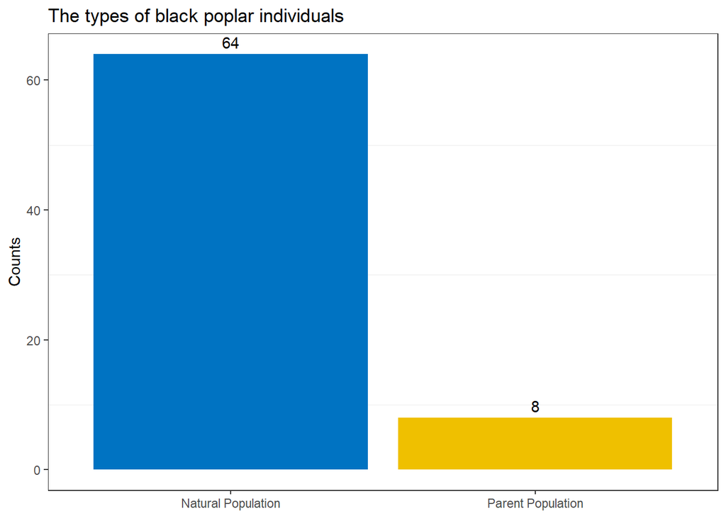

```r
x_labs = c("Natural Population", "Parent Population")

ggplot(wild_yr2000_new, aes(x = Classe)) +
  geom_bar(aes(fill = Classe)) +
  geom_text(stat = "count", aes(label = ..count..), vjust = -0.5) +
  scale_x_discrete(labels = x_labs) +
  ggpubr::fill_palette("jco") +
  labs(x = NULL, y = "Counts", title = "The types of black poplar individuals") +
  theme_bw() +
  theme(panel.grid.major = element_blank(),
        legend.position = "none")
```

The poplar individuals were consisted of poplars collected from natural population and from parent population.

Parent population means that these poplars have been used in a breeding program. Poplars are managed as hybrids. Hybrids are individuals created from 2 different species. In this case, hybrid poplar can be created from parents Populus deltoides x Populus nigra (P. nigra is the scientific name of black poplar). So poplar individuals collected from parent population means that these individuals are used as a parent in breeding hybrid poplars.

So let’s see their origins.

## Obj 3.1 The origins of poplar from natural and parent population

```r
# Insert a new column for "Region"
library(tibble)
wild_copy = wild_yr2000_new

wild_copy = tibble::add_column(wild_copy, "Region" = "NA", .after = "Population")

# Assigning the population to their region
for (j in c(1:nrow(wild_copy))) {
  if(wild_copy$Population[j] == "ValdeLoire" |
     wild_copy$Population[j] == "Selles_sur_Cher" |
    wild_copy$Population[j] == "Bonny"){
    wild_copy$Region[j] = "Centre_Val_de_Loire"
  }

  if(wild_copy$Population[j] == "Ramières" |
     wild_copy$Population[j] == "ValAllier" |
     wild_copy$Population[j] == "St_Jean_de_Maurienne" |
     wild_copy$Population[j] == "Meximieux" |
     wild_copy$Population[j] == "St_Genix_sur_Guiers"){
    wild_copy$Region[j] = "Auvergne_Rhone_Alpes"
  }

  if(wild_copy$Population[j] == "Tarbes" |
     wild_copy$Population[j] == "Nohèdes" |
     wild_copy$Population[j] == "Sauveterre" |
     wild_copy$Population[j] == "Cauterets"){
    wild_copy$Region[j] = "Occitanie"
  }

  if(wild_copy$Population[j] == "StPrivé" |
     wild_copy$Population[j] == "La_Celle_sur_Loire"){
    wild_copy$Region[j] = "Bourgogne_Franche_Comte"
  }

  if(wild_copy$Population[j] == "Sarrazin" |
     wild_copy$Population[j] == "Gave-Mauleon" |
     wild_copy$Population[j] == "Baudreix" |
     wild_copy$Population[j] == "Baliros" |
     wild_copy$Population[j] == "Assat"){
    wild_copy$Region[j] = "Nouvelle_Aquitaine"
  }

  if(wild_copy$Population[j] == "Pont_de_Cé" |
     wild_copy$Population[j] == "Cunault"){
    wild_copy$Region[j] = "Pays_de_la_Loire"
  }

  if(wild_copy$Population[j] == "Cazebonne"){
    wild_copy$Region[j] = "Bordeaux"
  }

}

lab_names = c("Natural Population", "Parent Population")
names(lab_names) = c("nigrapop", "parent 14x13")

x_labels = c("Auvergne Rhône Alpes", "Bordeaux",
             "Bourgogne Franche Comté", "Centre-Val de Loire",
             "Unknown", "Nouvelle Aquitaine",
             "Occitanie", "Pays de la Loire")

str(wild_copy)
```

```
## tibble [72 x 10] (S3: tbl_df/tbl/data.frame)
##  $ Classe            : Factor w/ 4 levels "coll. Nationale",..: 3 3 3 3 3 3 3 3 2 2 ...
##  $ Population        : Factor w/ 33 levels "?","Assat","Baliros",..: 29 18 16 1 10 25 27 1 23 23 ...
##  $ Region            : chr [1:72] "Auvergne_Rhone_Alpes" "Auvergne_Rhone_Alpes" "Bourgogne_Franche_Comte" "NA" ...
##  $ Clone             : Factor w/ 93 levels "6-J05","6-J13",..: 4 6 12 31 45 80 81 93 1 2 ...
##  $ Notemax.2010      : num [1:72] 4.4 4.5 3.83 3.6 3.17 ...
##  $ latence.93JE3.2010: num [1:72] 8.05 7.9 7.8 8.45 8 ...
##  $ nbsores.93JE3.2010: num [1:72] 17.5 33.7 27.2 23.1 37.9 56.7 38.4 35.9 16.8 29.2 ...
##  $ taille.93JE3.2010 : num [1:72] 3.7 4.4 5 3.6 4.1 ...
##  $ Res_vs_sus_note   : chr [1:72] "Susceptible" "Susceptible" "Susceptible" "Susceptible" ...
##  $ Res_vs_sus_lab    : chr [1:72] "Susceptible" "Susceptible" "Susceptible" "Susceptible" ...
```

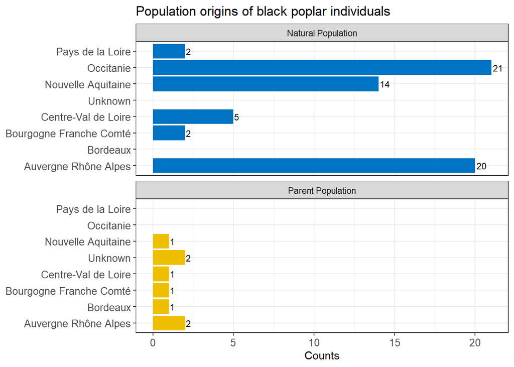

```r
wild_copy$Region = factor(wild_copy$Region)

ggplot(wild_copy, aes(x = Region)) +
  geom_bar(aes(fill = Classe)) +  # barchart
  ggpubr::fill_palette("jco") +
  coord_flip() +
  scale_x_discrete(labels = x_labels) +
  facet_wrap(~ Classe, labeller = labeller(Classe = lab_names), ncol = 1) +  # faceted by parents and natural pop
  labs( x = NULL, y = "Counts", title = "Population origins of black poplar individuals" ) +
  geom_text(stat = "count", aes(label = ..count..), hjust = -0.15, size = 3) +
  theme_bw() +
  theme(axis.text = element_text(size = 10),
        legend.position = "none")
```

## Obj 3.2 Comparison of resistance between poplars from natural population and from parent population

In this section, I would like to show you the resistance between the two populations. Are poplars from natural population resisting better to leaf rust than the poplars from parent population?

### Field resistance and spore size

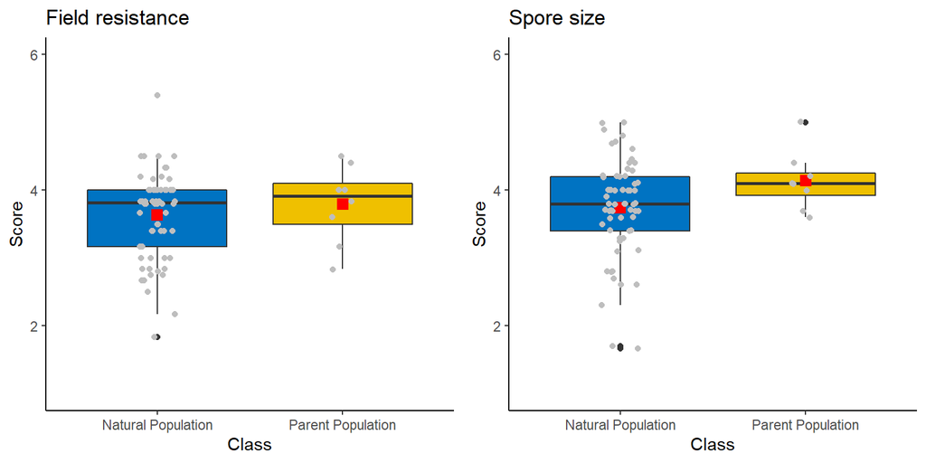

```r
# Summary statistics with aggregate function

# Length
aggregate = aggregate(wild_yr2000_new$Classe, by = list(Classe = wild_yr2000_new$Classe),
                       FUN = length)
names(aggregate)[2] = "length"

# Function mean
mean.fun = function(x){
  aggregate(x,
            by = list(Classe = wild_yr2000_new$Classe),
            FUN = mean)
}

# Function sd
sd.fun = function(x){
  aggregate(x,
            by = list(Classe = wild_yr2000_new$Classe),
            FUN = sd)
}

# Plotting the comparison
compare_NM = ggplot(wild_yr2000_new, aes(x = Classe, y = Notemax.2010)) +
  geom_boxplot(aes(fill= Classe)) +
  ggpubr::fill_palette("jco") +
  stat_summary(fun = "mean", geom = "point", size = 3, color = "red", shape = 15) +
  geom_jitter(color = "grey", width = .1) +
  labs(title = "Field resistance",
       x = "Class",
       y = "Score") +
  scale_x_discrete(limit = c("nigrapop", "parent 14x13"),
                   labels = c("Natural Population", "Parent Population")) +
  ylim(1, 6) +
  theme_classic() +
  theme(legend.position = "none")

# Spore size
compare_SS = ggplot(wild_yr2000_new, aes(x = Classe, y = taille.93JE3.2010)) +
  geom_boxplot(aes(fill = Classe)) +
  ggpubr::fill_palette("jco") +
  stat_summary(fun = "mean", geom = "point", size = 3, color = "red", shape = 15) +
  geom_jitter(color = "grey", width = .1) +
  labs(title = "Spore size",
       x = "Class",
       y = "Score") +
  scale_x_discrete(limit = c("nigrapop", "parent 14x13"),
                   labels = c("Natural Population", "Parent Population")) +
  ylim(1, 6) +
  theme_classic() +
  theme(legend.position = "none")

# Combining note max and spore size distribution
compare = ggarrange(compare_NM, compare_SS)
compare
```

In terms of spore size in the lab:  
The poplars from natural populations have lower spore size than the parents (on average). This shows the ability of the poplars from natural populations to better prevent the development of pathogen’s spores on their leaves, **in laboratory setting**. It also means that in the lab, P. nigra itself is able to prevent the development of the spore, rather than when it is paired with other Populus species in a breeding program.

### Latent period

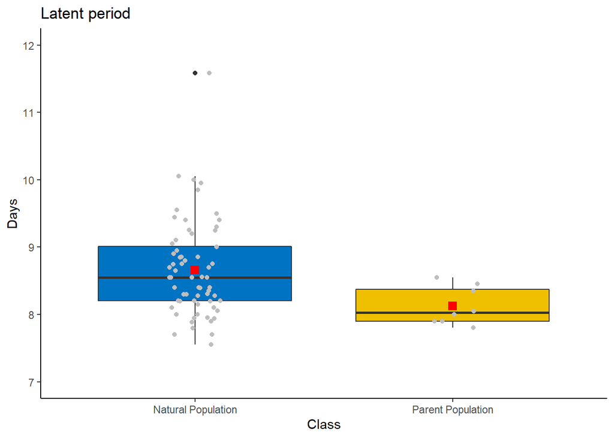

```r
# Latent period
compare_LP = ggplot(wild_yr2000_new, aes(x = Classe, y = latence.93JE3.2010)) +
  geom_boxplot(aes(fill = Classe)) +
  ggpubr::fill_palette("jco") +
  stat_summary(fun = "mean", geom = "point", size = 3, color = "red", shape = 15) +
  geom_jitter(color = "grey", width = .1) +
  labs(title = "Latent period",
       x = "Class",
       y = "Days") +
  scale_x_discrete(limit = c("nigrapop", "parent 14x13"),
                   labels = c("Natural Population", "Parent Population")) +
  ylim(7, 12) +
  theme_classic() +
  theme(legend.position = "none")

compare_LP
```

In terms of latent period in the lab: The poplars from natural populations start showing symptoms in a much later day than the poplars from the parent population. It shows the ability of the poplars from natural populations to prevent the accumulation of pathogen on the leaves.

When the poplars are able to prevent the accumulation of the pathogen, they are more likely to prevent the growth of the pathogen on the leaves. Thus when they start showing symptoms in a much later day, they tend to have fewer spores with smaller size on the leaves than the other poplars that show symptoms in an earlier day.

### Spore number

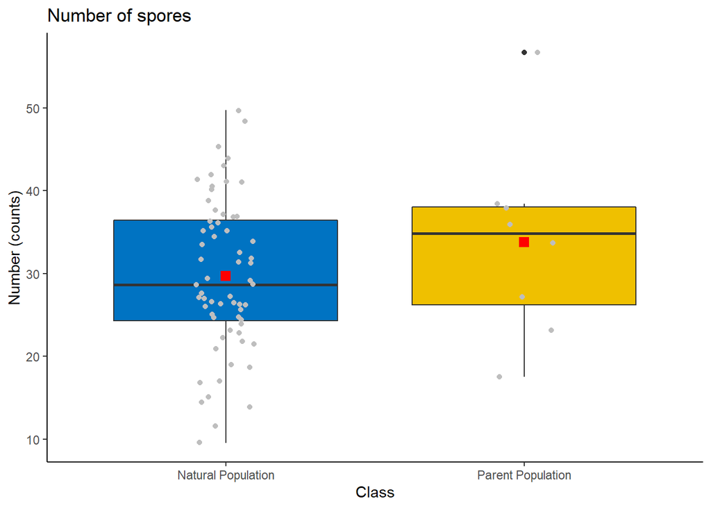

```r
# Number of spores
compare_NS = ggplot(wild_yr2000_new, aes(x = Classe, y = nbsores.93JE3.2010)) +
  geom_boxplot(aes(fill = Classe)) +
  ggpubr::fill_palette("jco") +
  stat_summary(fun = "mean", geom = "point", size = 3, color = "red", shape = 15) +
  geom_jitter(color = "grey", width = .1) +
  labs(title = "Number of spores",
       x = "Class",
       y = "Number (counts)") +
  scale_x_discrete(limit = c("nigrapop", "parent 14x13"),
                   labels = c("Natural Population", "Parent Population")) +
  theme_classic() +
  theme(legend.position = "none")

compare_NS
```

In terms of number of spores: The poplars from natural populations have fewer number of spores than the parent. It relates to the inhibiting actions of latent period, and it also leads to the smaller spore size.

# Obj 4 Correlation between field resistance and lab resistance

To observe the relationships between the parameters of resistance. Furthermore, to see if field resistance can be explained by the parameters of lab resistance or not.

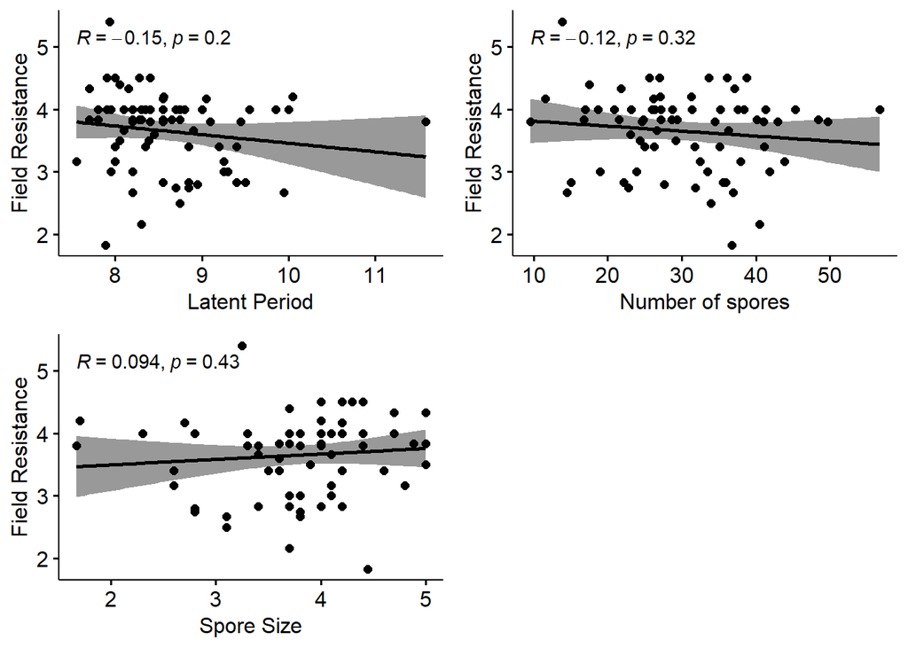

```r
LP_NM = ggpubr::ggscatter(wild_yr2000_new,
                          x = "latence.93JE3.2010", y = "Notemax.2010",
                          add = "reg.line", conf.int = TRUE,
                          cor.coef = TRUE, cor.method = "pearson",
                          xlab = "Latent Period", ylab = "Field Resistance")

NS_NM = ggpubr::ggscatter(wild_yr2000_new,
                          x = "nbsores.93JE3.2010", y = "Notemax.2010",
                          add = "reg.line", conf.int = TRUE,
                          cor.coef = TRUE, cor.method = "pearson",
                          xlab = "Number of spores", ylab = "Field Resistance")

SS_NM = ggpubr::ggscatter(wild_yr2000_new,
                          x = "taille.93JE3.2010", y = "Notemax.2010",
                          add = "reg.line", conf.int = TRUE,
                          cor.coef = TRUE, cor.method = "pearson",
                          xlab = "Spore Size", ylab = "Field Resistance")

corr = ggpubr::ggarrange(LP_NM, NS_NM, SS_NM)

corr
```

It seems that there are no clear correlation between field and lab resistance. It seems unclear whether lab resistance can explain or predict field resistance.

# Obj 5 Correlation between parameters of lab resistance

In this section, I want to evaluate the correlation between the components of lab resistance. I will just evaluate the correlation between two components: latent period (LP) and spore size (SS).

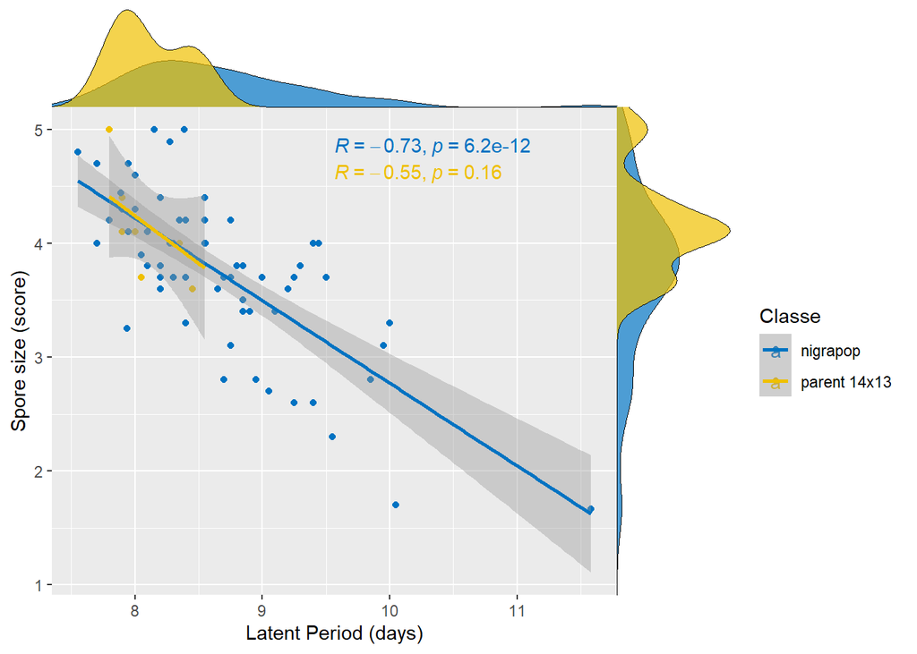

```r
# Designing the main correlation plot latence x taille
main_cor = ggplot(data = wild_yr2000_new, aes(x = latence.93JE3.2010,
                                              y = taille.93JE3.2010,
                                              color = Classe)) +
  labs(x = "Latent Period (days)", y = "Spore size (score)") +
  geom_point(aes(color = Classe)) +
  ggpubr::color_palette("jco") +
  stat_cor(method = "pearson", cor.coef.name = "R",
           digits = 2, label.x.npc = "center") +
  geom_smooth(method = "lm")

# Because I differentiated correlation for parent and nigrapop, I want to provide
# the density histogram for poplars from parent and nigrapop

# Density histogram for latent period, plotted at x axis
xdens = axis_canvas(main_cor, axis = "x") +  # create the canvas base
  geom_density(data = wild_yr2000_new,
               aes(x = latence.93JE3.2010, fill = Classe),
               alpha = 0.7, size = 0.2) +  # density histogram for latence
  ggpubr::fill_palette("jco")  # color palette for fill

# Density histogram for taille, plotted at y axis
ydens = axis_canvas(main_cor, axis = "y", coord_flip = TRUE) +
  geom_density(data = wild_yr2000_new,
               aes(x = taille.93JE3.2010, fill = Classe),
               alpha = 0.7, size = 0.2) +  # density histogram for taille
  coord_flip() +  # flipping the coordinate, 90 degrees
  ggpubr::fill_palette("jco")

# Adding xdens on the x axis of correlation plot
main_cor1 = cowplot::insert_xaxis_grob(main_cor, xdens,
                                       grid::unit(0.2, "null"),
                                       position = "top")

# Adding ydens on the y axis of correlation plot
main_cor2 = cowplot::insert_yaxis_grob(main_cor1, ydens,
                                       grid::unit(0.2, "null"),
                                       position = "right")

cowplot::ggdraw(main_cor2)
```

```r
# Saving the plot
ggsave("correlation_plot.png",
       device = "png",
       width = 15,
       height = 10,
       units = "cm",
       dpi = 300)
```

It seems that there is a clear correlation between the parameters of lab resistance (latent period and spore size).